# Simulate diffusion on a grid using Python

by [Christoph Gohlke](https://www.cgohlke.com)

Updated on June, 28, 2022

This notebook is released under the BSD 3-Clause license.

## References

This [Jupyter Notebook](https://jupyter.org/) uses the [Python 3](https://www.python.org) programming language, the [numpy](https://numpy.org/) library for n-dimensional array-programming and linear algebra, the [numba](https://numba.pydata.org/) Python compiler, and the [matplotlib](https://matplotlib.org/) library for plotting.

The [mean square displacement](https://en.wikipedia.org/wiki/Mean_squared_displacement) (MSD) of Brownian particles in n-dimensions Euclidean space is:

$$ MSD = \left<\left(x_1(t) - x_1(0)\right)^2 + \left(x_2(t) - x_2(0)\right)^2 + ... + \left(x_n(t) - x_n(0)\right)^2\right> = 2nDt $$

where $t$ is the time, $D$ the diffusion coefficient, $n$ the dimension, $x_n(t)$ the cartesian coordinate of a particle in dimension $n$ at time $t$, and $\left<\right>$ the ensemble average over all particles.

Some of the functions used in the first part of the simulation code:

- [`range(stop)`](https://docs.python.org/3/library/stdtypes.html#range) returns a sequence of integers from 0 to stop (excluding).
- [`print(objects)`](https://docs.python.org/3/library/functions.html#print) prints objects to the text stream file.
- [`numpy.zeros(shape, dtype)`](https://numpy.org/doc/stable/reference/generated/numpy.zeros.html) returns an array of specified shape and data type, initialized with zeros.
- [`numpy.random.randint(high, size)`](https://numpy.org/doc/stable/reference/random/generated/numpy.random.randint.html) returns an array of shape "size", initialized with random integers between 0 and high (excluding).
- [`numpy.take(array, indices, axis)`](https://numpy.org/doc/stable/reference/generated/numpy.take.html) returns elements at indices from an array along an axis.
- [`numpy.cumsum(array, axis)`](https://numpy.org/doc/stable/reference/generated/numpy.cumsum.html) returns the cumulative sum of an array along a specified axis. For example, `numpy.cumsum([[1, 2, 3], [4, 5, 6]], axis=1)` is `[[1, 3, 6], [4, 9, 15]]`.
- [`numpy.mean(array, axis)`](https://numpy.org/doc/stable/reference/generated/numpy.mean.html) returns the avarage of the elements along axis.
- [`numpy.arange(stop)`](https://numpy.org/doc/stable/reference/generated/numpy.arange.html) returns evenly spaced values up to stop.
- [`numpy.linalg.lstsq(a, b)`](https://numpy.org/doc/stable/reference/generated/numpy.linalg.lstsq.html) returns the least-squares solution to a linear matrix equation, i.e. it computes the vector `x` that approximatively solves the equation `a @ x = b`.
- [`array[..., numpy.newaxis]`](https://numpy.org/doc/stable/reference/constants.html#numpy.newaxis) appends a new dimension of size 1 to the array, e.g. to turn a vector into a matrix.
- [`array[index]`](https://numpy.org/doc/stable/user/basics.indexing.html) returns the value(s) of the array at the position(s) specified by index.

## Diffusion on a one-dimensional grid

```python
# import the numpy array-computing library
import numpy

# Define some variables to control the simulation:
# number of particles
particles = 1000

# duration of the simulation, i.e. the number of sampling periods
duration = 1000

# the sampling period in arbitrary time units
sampling_period = 1000

# probability that a particle moves in a certain direction during the sampling
# period. Given in number of time units of the sampling period
diffusion_speed = 10

# Allocate a two-dimensional array of integers, which can store
# the positions of all particles during the simulation.
positions = numpy.zeros((particles, duration), dtype=numpy.int32)

# Create a look-up-table of directions to move.
# This table will be indexed by random numbers in range 0 to `sampling_period`.
# TODO: the table can be extended by another axis to include movements
# in y and z directions.
directions = numpy.zeros(sampling_period, dtype=numpy.int32)
# move the particle in the positive direction
directions[0:diffusion_speed] = 1
# move the particle in the negative direction
directions[diffusion_speed : diffusion_speed * 2] = -1

# Run the simulation separately for all particles.
# TODO: this loop could be vectorized, i.e. below calculations could be done
# for all particles at once.
for particle in range(particles):

    # Get a random number between 0 and `sampling_period`
    # for all sampling periods in the duration of the simulation.
    random_numbers = numpy.random.randint(sampling_period, size=duration)

    # Index the first axis in the `directions` look-up-table with the random
    # numbers to obtain the relative moves of the particle for all sampling
    # periods.
    moves = numpy.take(directions, random_numbers, axis=0)

    # Set the first position of the particle to the origin
    # TODO: the initial position could be randomized.
    moves[0] = 0

    # Calculate all positions of the particle for the duration of the
    # simulation by cumulatively summing the relative moves.
    # The result is stored in the positions array.
    # TODO: to include obstacles in the simulation, the numpy.cumsum function
    # could be replaced by a custom function restricting movement in and
    # out of obstacles.
    positions[particle] = numpy.cumsum(moves, axis=0)


# Calculate the mean square displacement (MSD) at each sampling period
# by squaring all positions and averaging them over particles.
msd = numpy.mean(numpy.square(positions), axis=0)

# Calculate the diffusion coefficient D from the slope of the MSD values vs
# time. The slope is fitted by solving a linear equation system.
time = numpy.arange(duration)[..., numpy.newaxis]
slope = numpy.linalg.lstsq(time, msd, rcond=None)[0][0]
D = slope / 2

print(D * sampling_period)
```

```
9.638267114037498
```

### Plot the positions of some particles over time

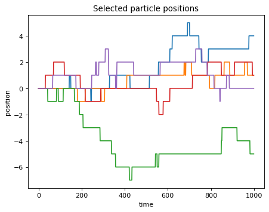

```python
from matplotlib import pyplot

pyplot.figure()
pyplot.title('Selected particle positions')
pyplot.xlabel('time')
pyplot.ylabel('position')
for i in range(5):
    pyplot.plot(positions[i])
pyplot.show()
```

### Plot all particle positions as a color-coded image

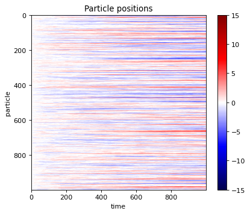

```python
pyplot.figure()
pyplot.title('Particle positions')
pyplot.xlabel('time')
pyplot.ylabel('particle')
minmax = numpy.max(numpy.abs(positions))
pyplot.imshow(positions, cmap='seismic', vmin=-minmax, vmax=minmax)
pyplot.colorbar()
pyplot.show()
```

### Plot a histogram of particle positions at the end of the simulation

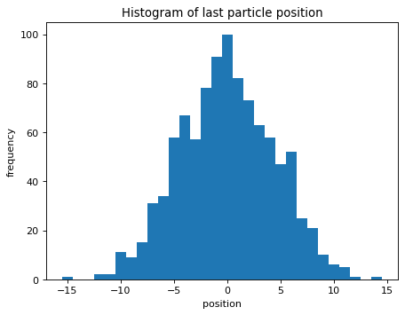

```python
pyplot.figure()
pyplot.title('Histogram of last particle position')
pyplot.xlabel('position')
pyplot.ylabel('frequency')
minmax = numpy.max(numpy.abs(positions))
pyplot.hist(positions[:, -1], numpy.arange(-minmax - 0.5, minmax + 0.5))
pyplot.show()
```

### Plot MSD and line fit

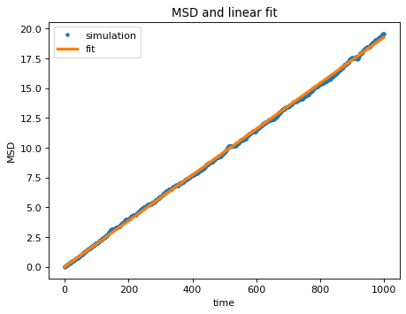

```python
pyplot.figure()
pyplot.title('MSD and linear fit')
pyplot.xlabel('time')
pyplot.ylabel('MSD')
pyplot.plot(time, msd, '.', label='simulation')
pyplot.plot(time, slope * time, '-', lw=3, label='fit')
pyplot.legend()
pyplot.show()
```

Remove all names defined above from the global namespace. Global names might interfere with following code.

```python
%reset -f
```

Import libraries and modules used in this document:

```python
import copy
import math

import numpy
import numba

from matplotlib import pyplot
from mpl_toolkits.mplot3d import Axes3D

import ipywidgets
```

## Diffusion on a n-dimensional grid

To make the code more modular, manageable, extensible, and reusable, it is refactored into small functions for simulation, particle counting, analysis, and plotting. The simulation model is extended to handle many dimensions. Hook functions allow customizing the initialization and restriction of particle movements. A simple detector "particle counter box" and methods to analyze and plot particle counts are added.

Diffusion in one, two, and three dimensions are simulated and compared.

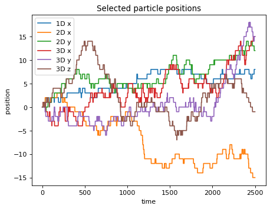

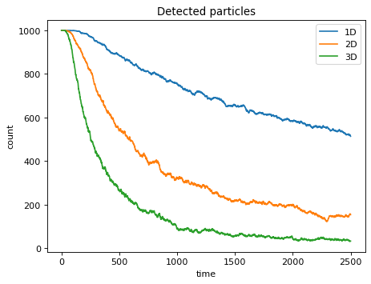

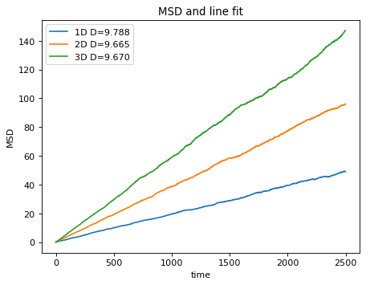

```
Wall time: 1.09 s
```

```python
def simulate_diffusion(
    dimensions,
    duration,
    sampling_period,
    number_particles,
    diffusion_speed,
    diffusion_model,
    diffusion_model_args,
    positions_init,
    positions_init_args,
):
    """Return nD positions of all particles for duration of simulation."""
    assert 0 < dimensions < 8
    assert sampling_period > diffusion_speed * (dimensions + 1) * 2

    # generate a look-up-table of directions to move.
    # this table will be indexed by random numbers in range 0 to
    # `sampling_period`
    directions = numpy.zeros((sampling_period, dimensions), dtype=numpy.int32)

    # generate combinations of all possible relative moves in all dimensions
    all_possible_directions = numpy.stack(
        numpy.meshgrid(*([-1, 0, 1],) * dimensions), -1
    ).reshape(-1, dimensions)

    index = 0
    for direction in all_possible_directions:
        if numpy.sum(numpy.abs(direction)) != 1:
            # particles can move only in one dimension per sampling_period
            continue

        # move the particle in the specified direction if random number is
        # between `index` and `index + diffusion_speed * dimensions`
        directions[index : index + diffusion_speed * dimensions] = direction

        index += diffusion_speed * dimensions

    # get a random number between 0 and `sampling_period`
    # for all particles and sampling periods in the duration of the simulation
    random_numbers = numpy.random.randint(
        sampling_period, size=(number_particles, duration)
    )

    # index the first axis in the `directions` look-up-table with the random
    # numbers to obtain the relative moves of all particles for all sampling
    # periods
    random_moves = numpy.take(directions, random_numbers, axis=0)

    # set the initial positions of particles using a hook function
    positions_init(random_moves, **positions_init_args)

    if diffusion_model is None:
        return random_moves

    # calculate the positions of particles from the random moves using a
    # hook function
    positions = diffusion_model(random_moves, **diffusion_model_args)

    return positions


def positions_init_origin(random_moves):
    """Set in-place initial position of particles to origin."""
    random_moves[:, 0] = 0


def diffusion_model_unconstrained(random_moves, **kwargs):
    """Diffusion with no constraints."""
    return numpy.cumsum(random_moves, axis=1)


def particle_counter_box(positions, counter_shape=None, counter_position=None):
    """Return number of particles in observation box over time.

    Also return the indices of particles that were counted.

    """
    dimensions = positions.shape[-1]
    if counter_shape is None:
        counter_shape = (1,) * dimensions  # one element
    if counter_position is None:
        counter_position = (0,) * dimensions  # center
    lower = tuple(p - s // 2 for p, s in zip(counter_position, counter_shape))
    upper = tuple(
        p + s // 2 + s % 2 for p, s in zip(counter_position, counter_shape)
    )
    in_box = numpy.all((positions >= lower) & (positions < upper), axis=-1)
    particle_counts = numpy.sum(in_box, axis=0)
    particles_counted = numpy.nonzero(numpy.any(in_box, axis=1))
    return particle_counts, particles_counted


def calculate_msd_d(positions):
    """Return mean square displacement and D of simulated positions."""
    number_particles, duration, dimensions = positions.shape
    msd = numpy.mean(
        numpy.square(positions - positions[:, 0:1, :]), axis=(0, -1)
    )
    time = numpy.arange(duration)[..., numpy.newaxis]
    slope = numpy.linalg.lstsq(time, msd, rcond=None)[0][0]
    d = slope / (2 * dimensions)
    return msd, d


def plot_positions(positions, selection=None, ax=None, title=None, label=None):
    """Plot positions of selected particles over duration of simulation."""
    number_particles, duration, dimensions = positions.shape
    if selection is None:
        selection = slice(1)  # first particle
    threed = dimensions > 2 and not isinstance(selection, int)
    ax_ = ax
    if ax is None:
        fig = pyplot.figure(figsize=(7.0, 7.0) if threed else None)
        ax = fig.add_subplot(111, projection='3d' if threed else None)
    if title is None:
        title = 'Selected particle positions'
    ax.set_title(title)
    if isinstance(selection, int):
        time = numpy.arange(duration)
        ax.set_xlabel('time')
        ax.set_ylabel('position')
        label = '' if label is None else label + ' '
        for i, dim in zip(range(dimensions - 1, -1, -1), 'xyzwvuts'):
            ax.plot(time, positions[selection, :, i], label=label + dim)
    elif dimensions == 1:
        time = numpy.arange(duration)
        ax.set_xlabel('time')
        ax.set_ylabel('x')
        for pos in positions[selection]:
            ax.plot(time, pos, label=label)
    elif dimensions == 2:
        ax.set_aspect('equal')
        ax.set_xlabel('x')
        ax.set_ylabel('y')
        for pos in positions[selection]:
            ax.plot(pos[:, 1], pos[:, 0], label=label)
    else:
        ax.set_xlabel('x')
        ax.set_ylabel('y')
        ax.set_zlabel('z')
        for pos in positions[selection]:
            ax.plot(pos[:, 2], pos[:, 1], pos[:, 0], label=label)
    if label is not None:
        ax.legend()
    if ax_ is None:
        pyplot.show()


def plot_msd(msd, d, dimensions=None, ax=None, labels=('simulation', 'fit')):
    """Plot MSD and line fit."""
    duration = msd.shape[0]
    time = numpy.arange(duration)
    ax_ = ax
    if ax is None:
        fig = pyplot.figure()
        ax = fig.add_subplot(111)
    ax.set_title('MSD and line fit')
    ax.set_xlabel('time')
    ax.set_ylabel('MSD')
    try:
        label0, label1 = labels
    except Exception:
        label0, label1 = None, None
    if dimensions:
        ax.plot(time, msd, '.', label=label0)
        ax.plot(time, d * 2 * dimensions * time, '-', lw=3, label=label1)
    else:
        ax.plot(time, msd, label=label0)
    if label0 or label1:
        ax.legend()
    if ax_ is None:
        pyplot.show()


def plot_particle_counts(particle_counts, ax=None, label=None):
    """Plot number of detected particles over time."""
    duration = particle_counts.shape[0]
    time = numpy.arange(duration)
    ax_ = ax
    if ax is None:
        fig = pyplot.figure()
        ax = fig.add_subplot(111)
    ax.set_title('Detected particles')
    ax.set_xlabel('time')
    ax.set_ylabel('count')
    ax.plot(time, particle_counts, label=label)
    if label:
        ax.legend()
    if ax_ is None:
        pyplot.show()


def example_nd_simulations():
    """Compare diffusion in 1, 2, and 3 dimensions."""

    # create three empty plots
    plots = []
    for _ in range(3):
        fig = pyplot.figure()
        plots.append(fig.add_subplot(111))

    # iterate over dimensions 1 to 3
    for dimensions in range(1, 4):

        # define simulation parameters
        simulation_args = {
            'dimensions': dimensions,
            'duration': 2500,
            'sampling_period': 1000,
            'number_particles': 1000,
            'diffusion_speed': 10,
            'positions_init': positions_init_origin,
            'positions_init_args': {},
            'diffusion_model': diffusion_model_unconstrained,
            'diffusion_model_args': {},
        }

        particle_counter_args = {
            'counter_position': (0,) * dimensions,
            'counter_shape': (10,) * dimensions,
        }

        # run simulation of model
        positions = simulate_diffusion(**simulation_args)

        # count particles
        particle_counts, particles_counted = particle_counter_box(
            positions, **particle_counter_args
        )

        # analyze positions and counted particles
        msd, D = calculate_msd_d(positions)

        # plot results of simulation and analysis
        label = f'{dimensions}D'
        plot_positions(positions, 0, ax=plots[0], label=label)
        plot_particle_counts(particle_counts, ax=plots[1], label=label)
        plot_msd(
            msd,
            D,
            ax=plots[2],
            labels=(
                f'{label} D={D * simulation_args["sampling_period"]:.3f}',
                None,
            ),
        )

    pyplot.show()


%time example_nd_simulations()
```

## Constrained diffusion in a box

To demonstrate diffusion under restrictions, particles are placed in a box. Particles can diffuse unconstrained within the box. Three different cases are explored when particles hit a box boundary:

- particles cannot leave the box.
- particles leaving the box immediately enter on the opposite side.
- particles leaving the box cannot re-enter (they are "absorbed" by the boundaries).

Hook functions are defined for each case and passed to the simulation function.

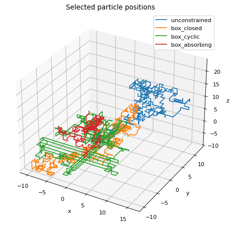

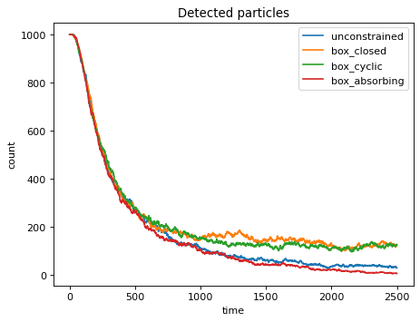

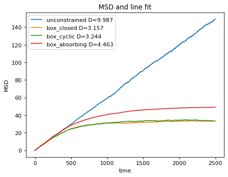

```
Wall time: 1.97 s
```

```python
def diffusion_model_box_closed(random_moves, box_shape):
    """Diffusion in a box. Particles cannot leave box."""
    positions = random_moves.copy()  # modify in-place
    number_particles, duration, dimensions = positions.shape
    lower = tuple(-s // 2 for s in box_shape)
    upper = tuple(s // 2 + s % 2 - 1 for s in box_shape)
    for time in range(1, duration):
        temp = positions[:, time]
        temp += positions[:, time - 1]  # cumsum axis=1
        numpy.clip(temp, lower, upper, out=temp)
    return positions


def diffusion_model_box_cyclic(random_moves, box_shape):
    """Diffusion in a box. Particles leaving box enter on opposite side."""
    positions = random_moves.copy()
    number_particles, duration, dimensions = positions.shape
    lower = tuple(-s // 2 for s in box_shape)
    for time in range(1, duration):
        temp = positions[:, time]
        temp += positions[:, time - 1]  # cumsum axis=1
        temp -= lower
        temp %= box_shape
        temp += lower
    return positions


def diffusion_model_box_absorbing(random_moves, box_shape):
    """Diffusion in a box. Particles leaving box never re-enter."""
    number_particles, duration, dimensions = random_moves.shape
    positions = numpy.cumsum(random_moves, axis=1)
    lower = tuple(-s // 2 for s in box_shape)
    upper = tuple(s // 2 + s % 2 for s in box_shape)
    leaving_box = numpy.argmax(
        numpy.any((positions < lower) | (positions >= upper), axis=-1), axis=-1
    )
    for particle in range(number_particles):
        index = leaving_box[particle]
        if 0 < index < duration - 1:
            positions[particle, index:] = positions[particle, index + 1]
    return positions


def example_box_model_simulations(dimensions=3):
    """Compare box diffusion models."""

    # define simulation parameters
    box_model_args = {'box_shape': (20,) * dimensions}

    simulation_args = {
        'dimensions': dimensions,
        'duration': 2500,
        'sampling_period': 1000,
        'number_particles': 1000,
        'diffusion_speed': 10,
        # 'diffusion_model': will be set later
        'diffusion_model_args': box_model_args,
        'positions_init': positions_init_origin,
        'positions_init_args': {},
    }

    particle_counter_args = {
        'counter_position': (0,) * dimensions,
        'counter_shape': (10,) * dimensions,
    }

    # create empty plots
    fig = pyplot.figure(figsize=(7.0, 7.0) if dimensions > 2 else None)
    plot0 = fig.add_subplot(111, projection='3d' if dimensions > 2 else None)
    fig = pyplot.figure()
    plot1 = fig.add_subplot(111)
    fig = pyplot.figure()
    plot2 = fig.add_subplot(111)

    # iterate over diffusion models
    for diffusion_model in (
        diffusion_model_unconstrained,
        diffusion_model_box_closed,
        diffusion_model_box_cyclic,
        diffusion_model_box_absorbing,
    ):
        # run simulation of model
        positions = simulate_diffusion(
            diffusion_model=diffusion_model, **simulation_args
        )

        # count particles
        particle_counts, particles_counted = particle_counter_box(
            positions, **particle_counter_args
        )

        # analyze positions and counted particles
        msd, D = calculate_msd_d(positions)

        # plot results of simulation and analysis
        model = diffusion_model.__name__[16:]
        plot_positions(positions, ax=plot0, label=model)
        plot_particle_counts(particle_counts, ax=plot1, label=model)
        plot_msd(
            msd,
            D,
            ax=plot2,
            labels=(
                f'{model} D={D * simulation_args["sampling_period"]:.3f}',
                None,
            ),
        )

    pyplot.show()


%time example_box_model_simulations()
```

## Membrane raft diffusion model

A membrane raft is approximated by a cylinder of a certain radius (in y, x dimensions) and thickness (in z dimension). It is placed at the origin. Particles moving into the cylinder are retained for some sampling periods and then released on the negative z side. A particle counter detector, elongated in the positive z direction, is placed at a distance in the y dimension (x=0, z=0).

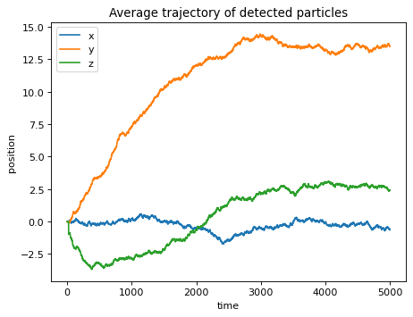

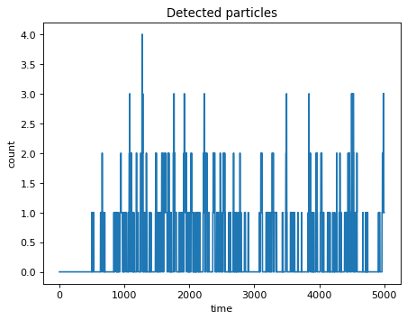

```
Wall time: 3.34 s
```

```python
@numba.jit
def diffusion_model_raft(random_moves, raft_shape, raft_delay):
    """Membrane raft diffusion model."""
    positions = random_moves.copy()
    number_particles, duration, dimensions = positions.shape
    assert dimensions == 3
    assert raft_delay >= 0
    length, radius = raft_shape
    radius *= radius
    for particle in range(number_particles):
        zyx = positions[particle, 0].copy()
        t = 1
        while t < duration:
            zyx += positions[particle, t]
            if (
                zyx[0] >= 0
                and zyx[0] < length
                and zyx[1] * zyx[1] + zyx[2] * zyx[2] < radius
            ):
                # particle entered raft, glue it for `raft_delay`
                zyx[0] = 0
                positions[particle, t : t + raft_delay] = zyx
                t += raft_delay
                if t < duration:
                    # release particle on -z side
                    zyx[0] = -1
                    positions[particle, t] = zyx
            else:
                positions[particle, t] = zyx
            t += 1
    return positions


def example_raft_simulation():
    """Run simulation of membrane raft model."""

    raft_model_args = {'raft_shape': (2, 10), 'raft_delay': 20}

    simulation_args = {
        'dimensions': 3,
        'duration': 5000,
        'sampling_period': 1000,
        'number_particles': 5000,
        'diffusion_speed': 10,
        'diffusion_model': diffusion_model_raft,
        'diffusion_model_args': raft_model_args,
        'positions_init': positions_init_origin,
        'positions_init_args': {},
    }

    particle_counter_args = {
        'counter_position': (50, 15, 0),
        'counter_shape': (100, 1, 1),
    }

    positions = simulate_diffusion(**simulation_args)

    particle_counts, particles_counted = particle_counter_box(
        positions, **particle_counter_args
    )

    msd, D = calculate_msd_d(positions)

    average_trajectory = numpy.average(positions[particles_counted], axis=0)
    plot_positions(
        average_trajectory[numpy.newaxis],
        0,
        title='Average trajectory of detected particles',
    )
    plot_particle_counts(particle_counts)

    return positions  # to analyze further


%time POSITIONS = example_raft_simulation()
```

### Plot the spatial distribution of particles over time

For visualizing the spatial distribution of all particles over the duration of the simulation, a multi-dimensional histogram of particle positions is calculated. The y and x dimensions are reduced to one radial dimension (`radius = hypot(x, y)`). The number of particles at a certain sampling period, z-position, and radius is counted and then normalized by the number of voxels at a certain radius. The three-dimensional histogram is plotted in log-scale as a series of color-coded 2D images using interactive Jupyter widgets.

```python
@numba.jit
def _histogram_zr(positions, axes=(0, 1, 2)):
    """Return (z, r) histograms of particles over duration of simulation."""
    number_particles, duration, dimensions = positions.shape
    zax, yax, xax = axes
    assert dimensions == 3
    radial = positions[..., :2].copy()
    zmin = radial[..., zax].min()
    radius = numpy.hypot(positions[..., yax], positions[..., xax])
    radius += 0.5
    radial[..., 0] -= zmin
    radial[..., 1] = radius
    zmax = radial[..., 0].max()
    rmax = radial[..., 1].max()
    hist = numpy.zeros((duration, zmax + 1, rmax + 1), dtype=numpy.uint32)
    for p in range(number_particles):
        for t in range(duration):
            z = radial[p, t, 0]
            r = radial[p, t, 1]
            hist[t, z, r] += 1
    return hist, (zmin, 0)


def _histogram_zr_norm(radius):
    """Return number of particles at radius for uniform distribution."""
    yx = numpy.mgrid[:radius, :radius]
    r = numpy.hypot(yx[0], yx[1])
    r += 0.5
    r = r.astype(numpy.int32)
    norm = numpy.bincount(r.ravel())
    norm = norm[:radius]
    norm[1:] *= 4
    return norm


def plot_histogram_zr(positions, axes=(0, 1, 2)):
    """Interactively plot histograms of (z, r) positions as log-image."""
    number_particles, duration, dimensions = positions.shape
    hist, (zmin, _) = _histogram_zr(positions, axes=axes)
    norm = _histogram_zr_norm(hist.shape[-1])
    hist = numpy.log10(numpy.where(hist > 0.0, hist, numpy.nan) / norm)

    cmap = copy.copy(pyplot.cm.get_cmap('bwr'))
    cmap.set_bad(color='black')
    vmax = math.log10(number_particles)

    def _plot(time):
        pyplot.figure(figsize=(4.8, 6.4))
        pyplot.title('normalized log10 histogram of positions')
        pyplot.xlabel('hypot(x, y)')
        pyplot.ylabel('z')
        pyplot.yticks(
            [0, -zmin, hist.shape[1] - 1], [zmin, 0, hist.shape[1] + zmin]
        )
        pyplot.imshow(
            hist[time], vmin=-vmax, vmax=vmax, cmap=cmap, origin='lower'
        )
        pyplot.colorbar()
        pyplot.show()

    ipywidgets.interact(
        _plot,
        time=ipywidgets.IntSlider(
            value=hist.shape[0] // 8,
            min=0,
            max=hist.shape[0] - 1,
            continuous_update=False,
        ),
    )


%time plot_histogram_zr(POSITIONS)
```

```
Wall time: 3.21 s
```

## Multiple particle types

The simulation code is extended to handle multiple types of particles of different diffusion speeds, diffusion models, and initial positions. The diffusion of particles of different types is simulated separately using the existing `simulate_diffusion` function. The positions of different particle types are then joined. This simulation mode does not allow for interacting or reacting particles.

Functions are added to initialize particle positions with a uniform distribution or known positions.

As an example, three diffusion simulations are compared:

1. particles restricted in a box.
2. faster diffusing, unconstrained particles.
3. a mixture of above particles.

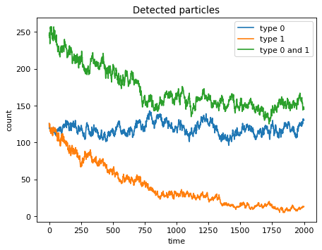

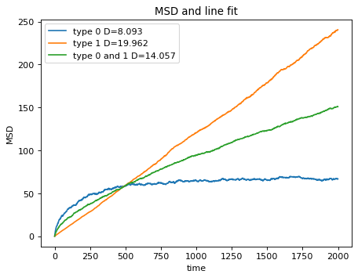

```
Wall time: 1.48 s
```

```python
def simulate_diffusion_pt(
    dimensions, duration, sampling_period, particle_types
):
    """Return positions of particles of different types."""
    return positions_join(
        [
            simulate_diffusion(
                dimensions,
                duration,
                sampling_period,
                number_particles=particle_type['number_particles'],
                diffusion_speed=particle_type['diffusion_speed'],
                diffusion_model=particle_type.get(
                    'diffusion_model', diffusion_model_unconstrained
                ),
                diffusion_model_args=particle_type.get(
                    'diffusion_model_args', {}
                ),
                positions_init=particle_type.get(
                    'positions_init', positions_init_origin
                ),
                positions_init_args=particle_type.get(
                    'positions_init_args', {}
                ),
            )
            for particle_type in particle_types
        ]
    )


def positions_join(positions_sequence):
    """Return concatenated positions arrays."""
    return numpy.concatenate(positions_sequence)


def positions_init_uniform(random_moves, init_shape=None, init_position=None):
    """Set initial position of particles to uniform distribution."""
    number_particles, duration, dimensions = random_moves.shape
    if init_position is None:
        init_position = (0,) * dimensions  # center
    if init_shape is None:
        init_position = (256,) * dimensions  # box
    for dim, (pos, size) in enumerate(zip(init_position, init_shape)):
        temp = numpy.random.randint(0, size, number_particles)
        temp += pos - size // 2
        random_moves[:, 0, dim] = temp


def positions_init_array(random_moves, init_positions):
    """Set initial position of particles using positions array."""
    random_moves[:, 0] = init_positions[:, 0]


def example_particle_type_simulations():
    """Compare diffusion of different and combined particle types."""

    particle_type_0 = [
        {
            'number_particles': 1000,
            'diffusion_speed': 10,
            'diffusion_model': diffusion_model_box_cyclic,
            'diffusion_model_args': {'box_shape': (20, 20, 20)},
            'positions_init': positions_init_uniform,
            'positions_init_args': {'init_shape': (20, 20, 20)},
        }
    ]
    particle_type_1 = [
        {
            'number_particles': 1000,
            'diffusion_speed': 20,
            'diffusion_model': diffusion_model_unconstrained,
            'diffusion_model_args': {},
            'positions_init': positions_init_uniform,
            'positions_init_args': {'init_shape': (20, 20, 20)},
        }
    ]

    simulation_args = {
        'dimensions': 3,
        'duration': 2000,
        'sampling_period': 1000,
    }

    particle_counter_args = {
        'counter_position': (0, 0, 0),
        'counter_shape': (10, 10, 10),
    }

    plots = []
    for _ in range(2):
        fig = pyplot.figure()
        plots.append(fig.add_subplot(111))

    for particle_types, label in zip(
        (particle_type_0, particle_type_1, particle_type_0 + particle_type_1),
        ('type 0', 'type 1', 'type 0 and 1'),
    ):
        positions = simulate_diffusion_pt(
            particle_types=particle_types, **simulation_args
        )

        particle_counts, particles_counted = particle_counter_box(
            positions, **particle_counter_args
        )

        msd, D = calculate_msd_d(positions)

        plot_particle_counts(particle_counts, ax=plots[0], label=label)
        plot_msd(
            msd,
            D,
            ax=plots[1],
            labels=(
                f'{label} D={D * simulation_args["sampling_period"]:.3f}',
                None,
            ),
        )

    pyplot.show()


%time example_particle_type_simulations()
```

## Fluorescence fluctuations

To approximate fluorescence fluctuations experiments, functions handling excitation of fluorophores and detection of emitted photons are defined.

### Laser Scanning

A confocal laser scanning system is approximated by exciting particles in a small volume for a certain number of sampling intervals (dwell time) before moving the volume to another position. The positions of the scanner can be static (point, 0D), circular, or rasterizing lines (1D), planes (2D), or volumes (3D).

### Point Spread Function (PSF)

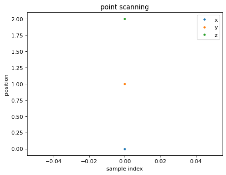

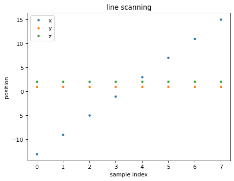

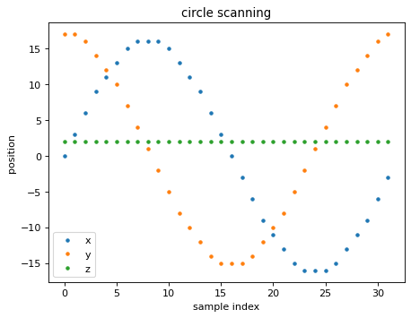

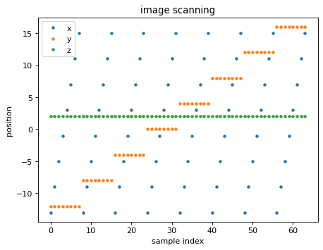

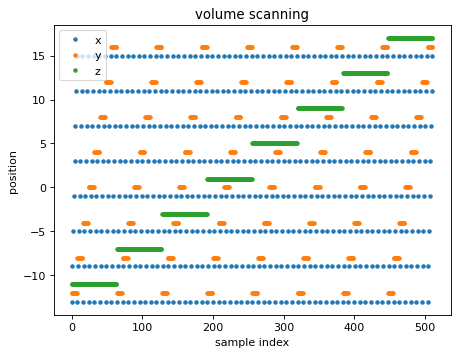

```
Wall time: 888 ms
```

```python
def psf_gaussian(psf_shape, psf_waist, psf_physical_size=1, psf_nphoton=2):
    """Return 3D gaussian approximation of PSF."""

    def f(index):
        s = psf_shape[index] // 2 * psf_physical_size
        c = numpy.linspace(-s, s, psf_shape[index])
        c *= c
        c *= -2.0 / (psf_waist[index] * psf_waist[index])
        return c

    psf = numpy.exp(
        numpy.sum(
            numpy.meshgrid(f(0), f(1), f(2), indexing='ij', sparse=False),
            axis=0,
        )
    )
    if psf_nphoton != 1:
        numpy.power(psf, psf_nphoton, out=psf)
    return psf


def laser_scanning(
    positions,
    particle_brightness,
    scanning_mode='point',
    scanning_position=(0, 0, 0),
    scanning_shape=(32, 32, 32),
    scanning_strides=(1, 1, 1),  # for raster
    scanning_samples=32,  # for circular
    scanning_dwelltime=1,
    scanning_intervals=(0, 0, 0, 0),  # eg. retrace
    scanning_intensity=1.0,
    scanning_psf=None,
    scanning_axes=(-3, -2, -1),
    scanning_offset=0.0,
    scanning_gain=1.0,
    scanning_gamma=1.0,
    scanning_bitdepth=12,
):
    """Return signal, scan times and positions of laser scanning."""
    if scanning_psf is None:
        scanning_psf = numpy.array(scanning_intensity, numpy.float64)
        scanning_psf.shape = 1, 1, 1
    else:
        scanning_psf = numpy.array(scanning_psf, numpy.float64)
        if scanning_intensity != 1.0:
            scanning_psf *= scanning_intensity
        assert scanning_psf.ndim == 3

    dimensions = {'circle': 0, 'point': 0, 'line': 1, 'image': 2, 'volume': 3}[
        scanning_mode
    ]

    if scanning_mode == 'circle':
        scan_positions = _scanning_circular(
            scanning_position, scanning_shape, scanning_strides, scanning_axes
        )
    else:
        scan_positions = _scanning_raster(
            scanning_position,
            scanning_shape,
            scanning_strides,
            scanning_axes,
            dimensions,
        )

    intensities, scan_times = _scanning_integrate(
        positions,
        scan_positions,
        particle_brightness,
        scanning_dwelltime,
        scanning_intervals,
        scanning_psf,
        dimensions,
    )

    intensities = intensities.squeeze()

    signal = _photon_counter(
        intensities,
        scanning_offset,
        scanning_gain,
        scanning_gamma,
        scanning_bitdepth,
    )
    return signal, scan_times, scan_positions


def _scanning_raster(position, shape, strides, axes, dims):
    """Return raster scan positions."""

    def arange(axis):
        s = shape[axis]
        d = strides[axis]
        p = position[axis] + ((s - 1) % (s // d)) // 2
        return numpy.arange(
            p - s // 2, p + s // 2 + s % 2, d, dtype=numpy.int32
        )

    ndims = len(axes)
    coordinates = [None] * ndims
    for i, ax in enumerate(axes):
        if ax % ndims >= ndims - dims:
            c = arange(i)
        else:
            c = numpy.array([position[i]], dtype=numpy.int32)
        coordinates[i] = c
    return numpy.moveaxis(
        numpy.stack(
            [
                numpy.transpose(v, axes)
                for v in numpy.meshgrid(*coordinates, indexing='ij')
            ]
        ),
        0,
        -1,
    )


def _scanning_circular(position, shape, samples, axes):
    """Return circular scan positions."""
    r = numpy.linspace(
        0, 2 * math.pi, samples, endpoint=False, dtype=numpy.float64
    )
    positions = numpy.empty((samples, 3), dtype=numpy.int32)
    s = numpy.sin(r)
    s *= shape[axes[-1]] / 2
    c = numpy.cos(r)
    c *= shape[axes[-2]] / 2
    positions[:, axes[-3]] = position[axes[-3]]
    positions[:, axes[-2]] = numpy.round(position[axes[-2]] + c)
    positions[:, axes[-1]] = numpy.round(position[axes[-1]] + s)
    return positions


@numba.jit
def _scanning_integrate(
    positions,
    scan_positions,
    particle_brightness,
    dwelltime,
    intervals,
    psf,
    dimensions,
):
    """Return laser scanning intensities and scan times."""
    interval = intervals[-dimensions - 1]
    duration = scan_positions.size // scan_positions.shape[-1] * dwelltime
    for i in range(dimensions):
        duration += intervals[-i - 1] * (scan_positions.shape[-i - 1] - 1)
    periods = (positions.shape[1] + interval) // (duration + interval)
    shape = (periods,) + scan_positions.shape[:-1]
    intensities = numpy.empty(shape, dtype=numpy.float64)
    intensities_ = intensities.flat
    scan_times = numpy.empty(intensities.size, dtype=numpy.float64)
    psf_shape = psf.shape
    psf_shape_2 = (psf_shape[0] // 2, psf_shape[1] // 2, psf_shape[2] // 2)
    sample = 0
    time = 0
    for volume in range(shape[0]):
        for image in range(shape[1]):
            for line in range(shape[2]):
                for pixel in range(shape[3]):
                    scan_times[sample] = time
                    sz, sy, sx = scan_positions[image, line, pixel]
                    sz -= psf_shape_2[0]
                    sy -= psf_shape_2[1]
                    sx -= psf_shape_2[2]
                    si = 0.0
                    for m in range(dwelltime):
                        for particle in range(positions.shape[0]):
                            pz = positions[particle, time, 0] - sz
                            py = positions[particle, time, 1] - sy
                            px = positions[particle, time, 2] - sx
                            if (
                                pz >= 0
                                and py >= 0
                                and px >= 0
                                and pz < psf_shape[0]
                                and py < psf_shape[1]
                                and px < psf_shape[2]
                            ):
                                pi = psf[pz, py, px]
                                pi *= particle_brightness[particle]
                                si += pi
                        time += 1
                    intensities_[sample] = si
                    sample += 1
                    time += intervals[-1]
                time += intervals[-2]
            time += intervals[-3]
        time += intervals[-4]
    return intensities, scan_times


def _photon_counter(
    intensities, offset=0.0, gain=1.0, gamma=1.0, bitdepth=32, poisson=True
):
    """Return Poisson distributed, digitized intensities."""
    max_int = 2 ** bitdepth - 1
    signal = intensities.astype(numpy.float64)
    signal -= offset
    signal *= gain
    if gamma != 1.0:
        signal /= max_int
        numpy.power(signal, 1 / gamma, out=signal)
        signal *= max_int
    if poisson:
        signal = numpy.random.poisson(signal)
        numpy.clip(signal, 0, max_int, out=signal)
    else:
        eps = numpy.finfo(numpy.float64).eps * 2
        numpy.clip(signal, 0, max_int - eps, out=signal)
        numpy.floor(signal, out=signal)
    if bitdepth > 32:
        dtype = numpy.uint64
    elif bitdepth > 16:
        dtype = numpy.uint32
    elif bitdepth > 8:
        dtype = numpy.uint16
    else:
        dtype = numpy.uint8
    return signal.astype(dtype, copy=False)


def _particle_ids(particle_types):
    """Return IDs of particles in positions axes."""
    number_particles = sum(
        particle_type['number_particles'] for particle_type in particle_types
    )
    ids = numpy.empty(number_particles, dtype=numpy.uint8)
    index = 0
    for i, particle_type in enumerate(particle_types):
        number_particles = particle_type['number_particles']
        ids[index : index + number_particles] = i
        index += number_particles
    return ids


def _particle_brightness(particle_types):
    """Return brightness of particles in positions axes."""
    return numpy.array(
        [pt.get('particle_brightness', 1.0) for pt in particle_types],
        dtype=numpy.float64,
    ).take(_particle_ids(particle_types))


def plot_timeseries(
    timeseries, vmin=0, vmax=None, title=None, label=None, ax=None
):
    """Plot timeseries."""
    ax_ = ax
    if ax is None:
        fig = pyplot.figure()
        ax = fig.add_subplot(111)
    if title is None:
        title = 'timeseries'
    ax.set_title(title)
    ax.set_xlabel('sample')
    ax.set_ylabel('intensity')
    ax.plot(timeseries, label=label)
    ax.set_ylim(bottom=vmin, top=vmax)
    if label:
        ax.legend()
    if ax_ is None:
        pyplot.show()


def plot_images(images, vmin=0, vmax=None, title=None):
    """Interactively plot series of images."""
    count, y, x = images.shape
    if title is None:
        title = 'Images'
    if vmax is None:
        vmax = images.max()

    def _plot(sample):
        pyplot.figure()
        pyplot.title(title)
        pyplot.imshow(images[sample], vmin=vmin, vmax=vmax)
        pyplot.colorbar()
        pyplot.show()

    ipywidgets.interact(
        _plot,
        sample=ipywidgets.IntSlider(
            value=0, min=0, max=count - 1, continuous_update=False
        ),
    )


def example_scan_positions():
    """Plot scan positions of different scanning modes."""
    scanning_position = (2, 1, 0)
    scanning_shape = (32, 32, 32)
    scanning_strides = (4, 4, 4)  # for raster
    scanning_samples = 32  # for circular
    scanning_axes = (-3, -2, -1)

    for scanning_mode in ('point', 'line', 'circle', 'image', 'volume'):

        dimensions = {
            'circle': 0,
            'point': 0,
            'line': 1,
            'image': 2,
            'volume': 3,
        }[scanning_mode]

        if scanning_mode == 'circle':
            scan_positions = _scanning_circular(
                scanning_position,
                scanning_shape,
                scanning_samples,
                scanning_axes,
            )
        else:
            scan_positions = _scanning_raster(
                scanning_position,
                scanning_shape,
                scanning_strides,
                scanning_axes,
                dimensions,
            )
        scan_positions.shape = (-1, 3)

        fig = pyplot.figure()
        ax = fig.add_subplot(111)
        ax.set_title(f'{scanning_mode} scanning')
        ax.set_xlabel('sample index')
        ax.set_ylabel('position')
        ax.plot(scan_positions[:, 2], '.', label='x')
        ax.plot(scan_positions[:, 1], '.', label='y')
        ax.plot(scan_positions[:, 0], '.', label='z')
        ax.legend()
        pyplot.show()


%time example_scan_positions()
```

### Point FCS and Photon Counting Histogram (PCH)

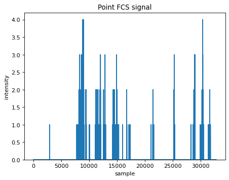

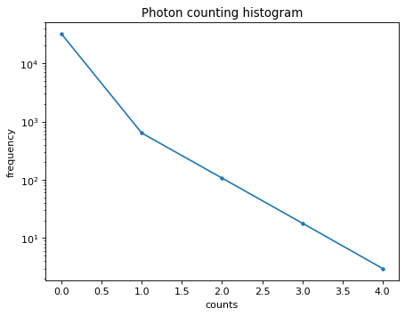

```
Wall time: 13.3 s
```

```python
def calculate_pch(photon_counts, maxcount=None, bins=10):
    """Return frequency of number of photons from observation volume."""
    if maxcount is None:
        maxcount = numpy.max(photon_counts)
    if maxcount <= bins:
        hist = numpy.bincount(photon_counts, minlength=maxcount)
        bins = numpy.arange(len(hist), dtype=numpy.int32)
    else:
        hist, bins = numpy.histogram(photon_counts, bins, (0, maxcount))
        bins += (bins[1] - bins[0]) / 2
        bins = bins[:-1]
    return hist, bins


def plot_pch(pch, bins, ax=None, label=None):
    """Plot photon counting histogram."""
    ax_ = ax
    if ax is None:
        fig = pyplot.figure()
        ax = fig.add_subplot(111)
    ax.set_title('Photon counting histogram')
    ax.set_xlabel('counts')
    ax.set_ylabel('frequency')
    ax.semilogy(bins, pch, '.-', label=label)
    # ax.set_ylim(bottom=1)
    if label:
        ax.legend()
    if ax_ is None:
        pyplot.show()


def example_point_fcs():
    """Laser scanning example."""

    # physical_size = 0.05  # micrometer per pixel
    # physical_time = 1.0  # microseconds per sampling period

    simulation_args = {
        'dimensions': 3,
        'duration': 2 ** 15,
        'sampling_period': 1000,
    }

    particle_types = [
        {
            'number_particles': 1000,
            'diffusion_speed': 10,
            'diffusion_model': diffusion_model_box_cyclic,
            'diffusion_model_args': {'box_shape': (256, 256, 256)},
            'positions_init': positions_init_uniform,
            'positions_init_args': {'init_shape': (256, 256, 256)},
            'particle_brightness': 1.0,
        },
        {
            'number_particles': 1000,
            'diffusion_speed': 20,
            'diffusion_model': diffusion_model_box_cyclic,
            'diffusion_model_args': {'box_shape': (256, 256, 256)},
            'positions_init': positions_init_uniform,
            'positions_init_args': {'init_shape': (256, 256, 256)},
            'particle_brightness': 2.0,
        },
    ]

    scanning_args = {
        'scanning_mode': 'point',
        'scanning_position': (0, 0, 0),
        'scanning_shape': (256, 256, 256),
        'scanning_strides': (8, 8, 8),  # for raster
        'scanning_samples': 32,  # for circular
        'scanning_dwelltime': 1,
        'scanning_intervals': (0, 0, 0, 0),  # eg. retrace
        'scanning_intensity': 1.0,
        'scanning_axes': (-3, -2, -1),
        'scanning_offset': 0.0,
        'scanning_gain': 1.0,
        'scanning_gamma': 1.0,
        'scanning_bitdepth': 12,
    }

    psf_args = {
        'psf_shape': (63, 31, 31),
        'psf_waist': (0.5, 0.25, 0.25),
        'psf_physical_size': 0.05,
        'psf_nphoton': 2,
    }

    positions = simulate_diffusion_pt(
        particle_types=particle_types, **simulation_args
    )

    scan_signal, scan_times, scan_positions = laser_scanning(
        positions,
        particle_brightness=_particle_brightness(particle_types),
        scanning_psf=psf_gaussian(**psf_args),
        **scanning_args,
    )

    pch, pch_bins = calculate_pch(scan_signal)

    plot_timeseries(scan_signal, title='Point FCS signal')
    plot_pch(pch, pch_bins)


%time example_point_fcs()
```

### Camera

A digital widefield camera is approximated by counting photons for a certain number of sampling intervals along all but two dimensions (usually y and x). Common properties of digital cameras are detector shape (pixel resolution), exposure time, binning of pixels, gain, offset, gamma, and bit depth.

### Photomultiplier

A photomultiplier simply integrates all photons for a certain number of sampling intervals.

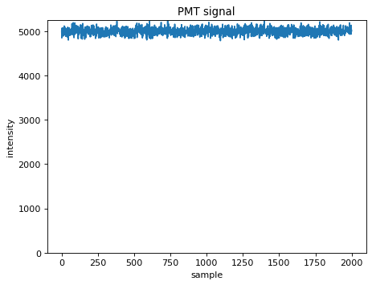

```
Wall time: 1.32 s
```

```python
def detector_pmt(
    intensities,
    pmt_exposure=1,
    pmt_offset=0.0,
    pmt_gain=1.0,
    pmt_gamma=1.0,
    pmt_bitdepth=16,
):
    """Return digitized time series of intensities in whole scene."""
    intensities = numpy.sum(intensities, axis=0)
    if pmt_exposure > 1:
        size = intensities.size
        if size % pmt_exposure:
            intensities = intensities.resize(
                (size + pmt_exposure - size % pmt_exposure,)
            )
        intensities = numpy.sum(
            intensities.reshape((pmt_exposure, -1)), axis=0
        )
    return _photon_counter(
        intensities, pmt_offset, pmt_gain, pmt_gamma, pmt_bitdepth
    )


def detector_camera(
    positions,
    intensities,
    camera_shape=(256, 256),
    camera_position=(0, 0),
    camera_exposure=1,
    camera_binning=(1, 1),
    camera_axes=(-2, -1),
    camera_offset=0.0,
    camera_gain=1.0,
    camera_gamma=1.0,
    camera_bitdepth=12,
):
    """Return digitized time series of 2D intensity images."""
    images = _detector_camera(
        positions,
        intensities,
        camera_shape,
        camera_position,
        camera_exposure,
        camera_binning,
        camera_axes,
    )
    return _photon_counter(
        images, camera_offset, camera_gain, camera_gamma, camera_bitdepth
    )


@numba.jit
def _detector_camera(
    positions,
    intensities,
    shape=(256, 256),
    position=(0, 0),
    exposure=1,
    binning=(1, 1),
    axes=(-2, -1),
):
    """ """
    yax, xax = axes
    ymin = position[0] - shape[0] // 2
    ymax = position[0] + shape[0] // 2 + shape[0] % 2
    xmin = position[1] - shape[1] // 2
    xmax = position[1] + shape[1] // 2 + shape[1] % 2
    images = numpy.zeros(
        (
            positions.shape[1] // exposure,
            shape[0] // binning[0],
            shape[1] // binning[1],
        ),
        dtype=numpy.uint32,
    )
    for p in range(positions.shape[0]):
        for t in range(positions.shape[1]):
            y = positions[p, t, yax]
            x = positions[p, t, xax]
            if y >= ymin and y < ymax and x >= xmin and x < xmax:
                images[
                    t // exposure,
                    (y - ymin) // binning[0],
                    (x - xmin) // binning[1],
                ] += intensities[p, t]
    return images


def excitation_ambient(positions, particle_types, ambient_intensity=1.0):
    """Return intensities of fluorophores excited by ambient light."""
    intensities = numpy.empty(positions.shape[:2], dtype=numpy.float64)
    intensities[..., :] = ambient_intensity
    intensities *= _particle_brightness(particle_types)[..., numpy.newaxis]
    return intensities


def example_detector_types():
    """Compare detector types."""

    simulation_args = {
        'dimensions': 3,
        'duration': 2000,
        'sampling_period': 1000,
    }

    particle_types = [
        {
            'number_particles': 1000,
            'diffusion_speed': 10,
            'diffusion_model': diffusion_model_box_cyclic,
            'diffusion_model_args': {'box_shape': (20, 20, 20)},
            'positions_init': positions_init_uniform,
            'positions_init_args': {'init_shape': (20, 20, 20)},
            'particle_brightness': 4.0,
        },
        {
            'number_particles': 1000,
            'diffusion_speed': 20,
            'diffusion_model': diffusion_model_unconstrained,
            'diffusion_model_args': {},
            'positions_init': positions_init_uniform,
            'positions_init_args': {'init_shape': (20, 20, 20)},
            'particle_brightness': 1.0,
        },
    ]

    detector_pmt_args = {
        'pmt_exposure': 1,
        'pmt_offset': 0.0,
        'pmt_gain': 1.0,
        'pmt_gamma': 1.0,
        'pmt_bitdepth': 16,
    }

    detector_camera_args = {
        'camera_shape': (32, 32),
        'camera_position': (0, 0),
        'camera_exposure': 1,
        'camera_binning': (1, 1),
        'camera_axes': (-2, -1),
        'camera_offset': 0.0,
        'camera_gain': 1.0,
        'camera_gamma': 1.0,
        'camera_bitdepth': 12,
    }

    positions = simulate_diffusion_pt(
        particle_types=particle_types, **simulation_args
    )

    intensities = excitation_ambient(positions, particle_types)

    pmt_signal = detector_pmt(intensities, **detector_pmt_args)

    camera_images = detector_camera(
        positions, intensities, **detector_camera_args
    )

    plot_images(camera_images, title='Camera signal')
    plot_timeseries(pmt_signal, title='PMT signal')


%time example_detector_types()
```

## To be continued

This notebook is work in progress.

The code is not well tested and documented. Use at your own risk.

## System information

Print information about the software used to generate this document.

```python
def system_info():
    """Return information about Python and libraries."""
    import sys
    import datetime
    import numpy
    import numba
    import matplotlib
    import notebook
    import ipywidgets
    import widgetsnbextension

    return '\n'.join(
        (
            sys.executable,
            f'Python {sys.version}',
            '',
            f'numpy {numpy.__version__}',
            f'numba {numba.__version__}',
            f'matplotlib {matplotlib.__version__}',
            f'notebook {notebook.__version__}',
            f'ipywidgets {ipywidgets.__version__}',
            f'widgetsnbextension {widgetsnbextension.__version__}',
            '',
            str(datetime.datetime.now()),
        )
    )


print(system_info())
```

```
x:\python38\python.exe
Python 3.8.8 (tags/v3.8.8:024d805, Feb 19 2021, 13:18:16) [MSC v.1928 64 bit (AMD64)]

numpy 1.19.5
numba 0.52.0
matplotlib 3.3.4
notebook 6.2.0
ipywidgets 7.6.3
widgetsnbextension 3.5.1

2021-03-21 10:29:49.392929
```